# StatR503 Final Project V4

Eugene Chua

June 30, 2017

### Introduction

This is a real estate dataset placed on Kaggle which I found recently while researching for the final class project. The dependent variable of interest is obviously house prices. This dataset has up to 80 explanatory variables describing (almost) every aspect of residential homes in Ames, Iowa. The goal of this contest is to predict the sales price of each house in the test set.

Submissions are actually evaluated on **RMSE** between the logarithm of the predicted value and the logarithm of the observed sales price. The details can be obtained here: https://www.kaggle.com/c/house-prices-advanced-regression-techniques#evaluation

Reading the training dataset

```r
RealEstateTrain<-read.csv("C:/Users/Eugene Chua/Documents/Real_Estate_train.csv",header=TRUE)

dim(RealEstateTrain)
```

```
## [1] 1460   81
```

```r
colnames(RealEstateTrain)
```

```
##  [1] "Id"            "MSSubClass"    "MSZoning"      "LotFrontage"
##  [5] "LotArea"       "Street"        "Alley"         "LotShape"
##  [9] "LandContour"   "Utilities"     "LotConfig"     "LandSlope"
## [13] "Neighborhood"  "Condition1"    "Condition2"    "BldgType"
## [17] "HouseStyle"    "OverallQual"   "OverallCond"   "YearBuilt"
## [21] "YearRemodAdd"  "RoofStyle"     "RoofMatl"      "Exterior1st"
## [25] "Exterior2nd"   "MasVnrType"    "MasVnrArea"    "ExterQual"
## [29] "ExterCond"     "Foundation"    "BsmtQual"      "BsmtCond"
## [33] "BsmtExposure"  "BsmtFinType1"  "BsmtFinSF1"    "BsmtFinType2"
## [37] "BsmtFinSF2"    "BsmtUnfSF"     "TotalBsmtSF"   "Heating"
## [41] "HeatingQC"     "CentralAir"    "Electrical"    "X1stFlrSF"
## [45] "X2ndFlrSF"     "LowQualFinSF"  "GrLivArea"     "BsmtFullBath"
## [49] "BsmtHalfBath"  "FullBath"      "HalfBath"      "BedroomAbvGr"
## [53] "KitchenAbvGr"  "KitchenQual"   "TotRmsAbvGrd"  "Functional"
## [57] "Fireplaces"    "FireplaceQu"   "GarageType"    "GarageYrBlt"
## [61] "GarageFinish"  "GarageCars"    "GarageArea"    "GarageQual"
## [65] "GarageCond"    "PavedDrive"    "WoodDeckSF"    "OpenPorchSF"
## [69] "EnclosedPorch" "X3SsnPorch"    "ScreenPorch"   "PoolArea"
## [73] "PoolQC"        "Fence"         "MiscFeature"   "MiscVal"
## [77] "MoSold"        "YrSold"        "SaleType"      "SaleCondition"
## [81] "SalePrice"
```

There are obviously many predictors in this dataset. For me, I am mentally categorising them into these general broad categories. The predictor ranges from the overall physical qualities of the building *OverallQal*,*HouseStyle*,*RoofStyle*,*ExterQaul* etc..to the space properties of the house *TotalBsmtSF* and then to location related variables such as *Neighbourhood*, *Condition1*.

```r
summary(RealEstateTrain$SalePrice)
```

```
##    Min. 1st Qu.  Median    Mean 3rd Qu.    Max.
##   34900  130000  163000  180900  214000  755000
```

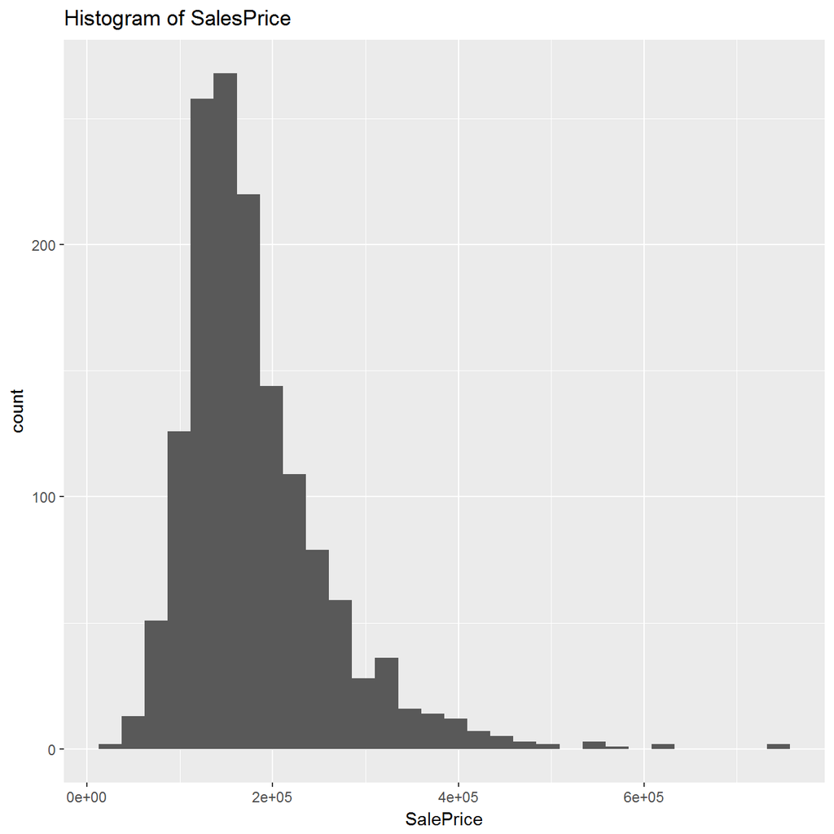

```r
#Minimum Sales Price is > than 0. At least I wont have any of these stupid incidence whereby Sales Price is 0

#Visualizing in a histogram
library(ggplot2)

ggplot(RealEstateTrain,aes(x=SalePrice)) + geom_histogram() + ggtitle("Histogram of SalesPrice")
```

```r
library(e1071)
skewness(RealEstateTrain$SalePrice)
```

```
## [1] 1.879009
```

I chose to visualize the the distribution of the dependent variable - *Sales Price* via a histogram. From what it seems, Sales Price deviates from the normal distribution and has appreciable positive skewness. This is proven by the skewness score which I calculated using the e1071 package - which is greater than +1. A question now looms - should the dependent variable be transform, and how will it affect the interpretability of the model?

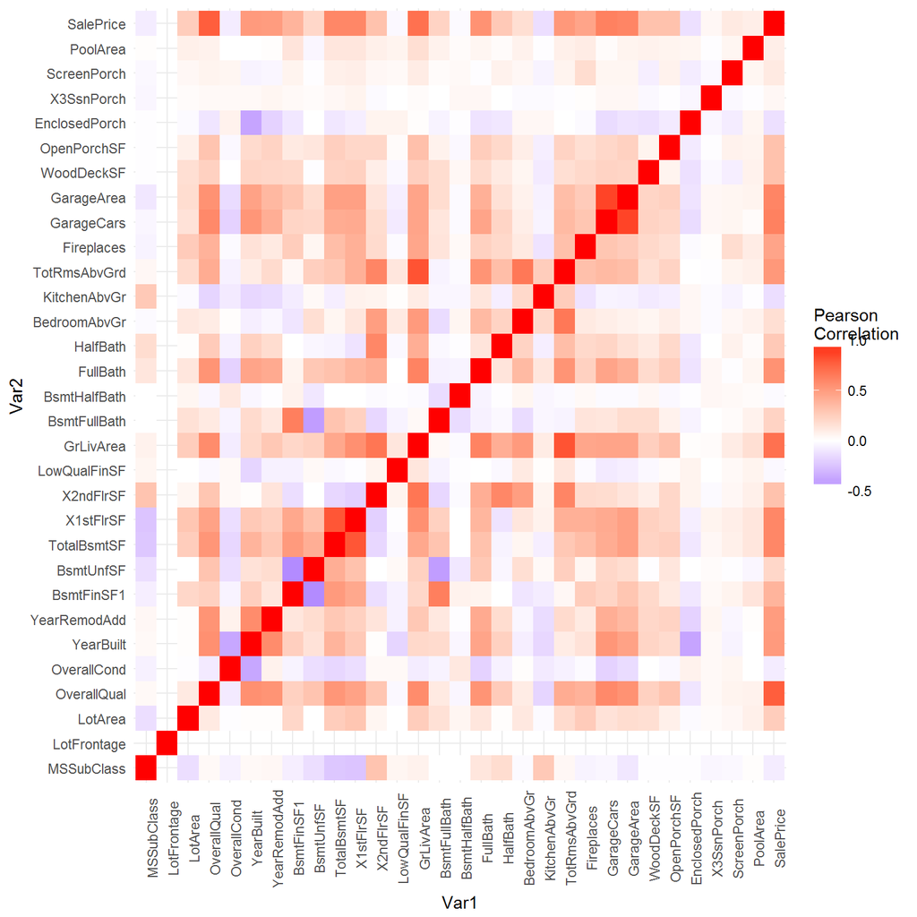

```r
TrainCor<-RealEstateTrain[,c(2,4,5,18:21,35,38:39,44:53,55,57,62:63,67:72,81)]

TrainCormat<-round(cor(TrainCor),2)

library(reshape2)
 TrainMeltCor<-melt(TrainCormat,na.rm=TRUE)

library(ggplot2)
 ggplot(TrainMeltCor,aes(x=Var1,y=Var2,fill=value)) + geom_tile() + scale_fill_gradient2(low="blue",high="red",mid="white",space="Lab",name="Pearson\nCorrelation") + theme_minimal() + theme(axis.text.x=element_text(angle=90))
```

To explore the relationship between the numeric variables, I ran a correlation heatmap. From the correlation heatmap plot, I can already see some variables that are highly correlated among themselves. These variables of concern are *GarageCars* & *GarageArea*, *TotalBsmtSF* & *X1stFlrSF*.There is a real need to take a closer look at these variables with the risk of multicollinearity that these highly correlated variables may pose.

```r
round(cor(RealEstateTrain[,c(62,63)]),2)
```

```
##            GarageCars GarageArea
## GarageCars       1.00       0.88
## GarageArea       0.88       1.00
```

```r
round(cor(RealEstateTrain[,c(39,44)]),2)
```

```
##             TotalBsmtSF X1stFlrSF
## TotalBsmtSF        1.00      0.82
## X1stFlrSF          0.82      1.00
```

I ran the Pearson correlation for these affected variables and with correlation scores of above 0.8, it indeed shows how highly correlated these variables are. Going forward in the latter stages of the analysis, I will have to carefully evaluate whether to include these variables through some feature extraction procedures.

Next, I will explore the relationship between SalePrice and some categorical variables; for example *OverallQual* & *HouseStyle*

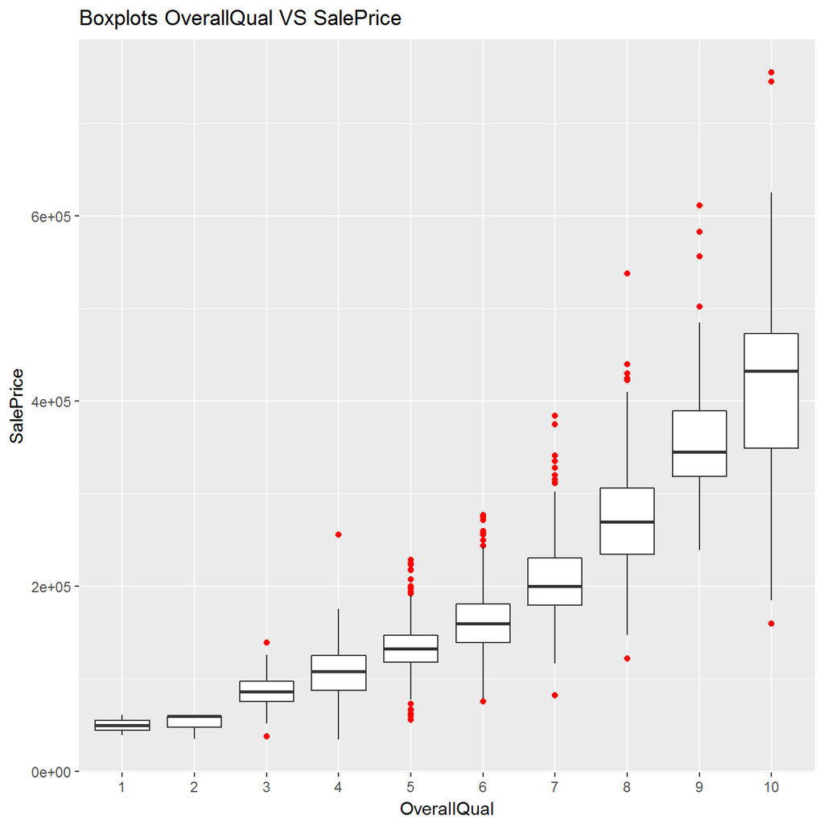

```r
RealEstateTrain$OverallQual<-factor(RealEstateTrain$OverallQual,levels=c(1,2,3,4,5,6,7,8,9,10))
ggplot(RealEstateTrain,aes(x=OverallQual,y=SalePrice)) + geom_boxplot(outlier.colour="red") + ggtitle("Boxplots OverallQual VS SalePrice")
```

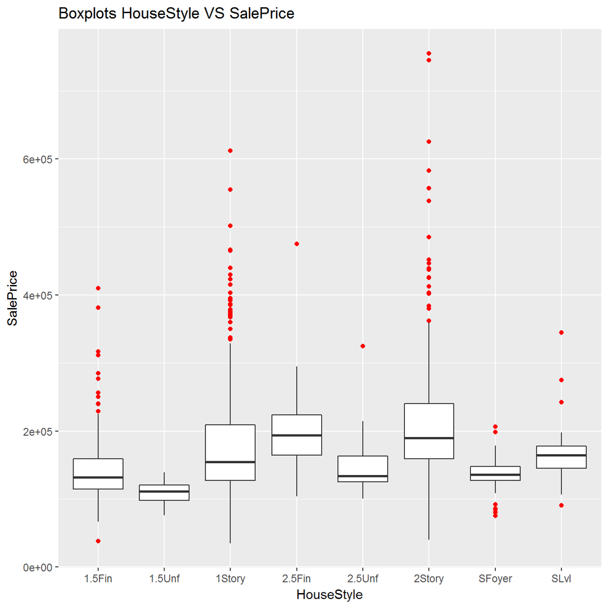

```r
ggplot(RealEstateTrain,aes(x=HouseStyle,y=SalePrice)) + geom_boxplot(outlier.colour="red") + ggtitle("Boxplots HouseStyle VS SalePrice")
```

The first boxplot shows that there is a clear positive linear relationship between the *OverallQual* & *SalePrice* of individual houses. It is obvious that the Sale Price of the house is strongly related to the overall material and finish quality of the house. In contrast, we do not see much of a relationship between *HouseStyle* & *SalePrice*

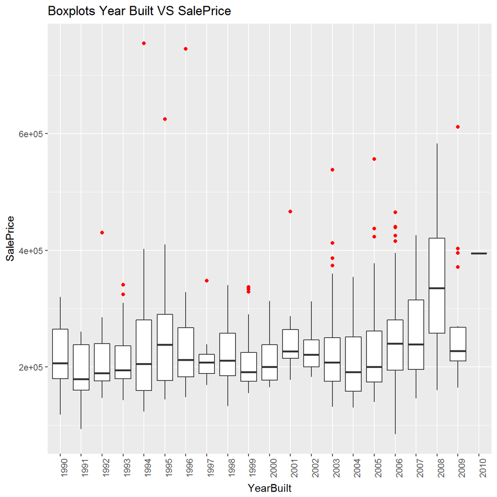

```r
#Subsetting from year 1990 onwards
RealEstateSubset<-subset(RealEstateTrain,YearBuilt>=1990)
RealEstateSubset$YearBuilt<-as.factor(RealEstateSubset$YearBuilt)
ggplot(RealEstateSubset,aes(x=YearBuilt,y=SalePrice)) + geom_boxplot(outlier.colour="red") + ggtitle("Boxplots Year Built VS SalePrice") +
  theme(axis.text.x=element_text(angle=90))
```

From this boxplot generated, we can see that the median Sale Price generally increase towards the last few years. Indeed it make sense that new houses command a higher sales price.

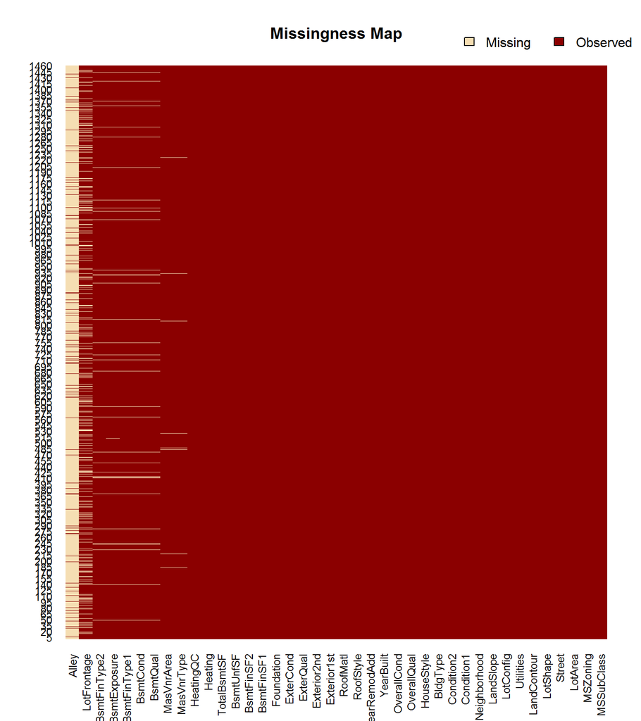

```r
library(Amelia)
#Lets have a macro visualization of missing values first

missmap(RealEstateTrain[,c(2:41)])
```

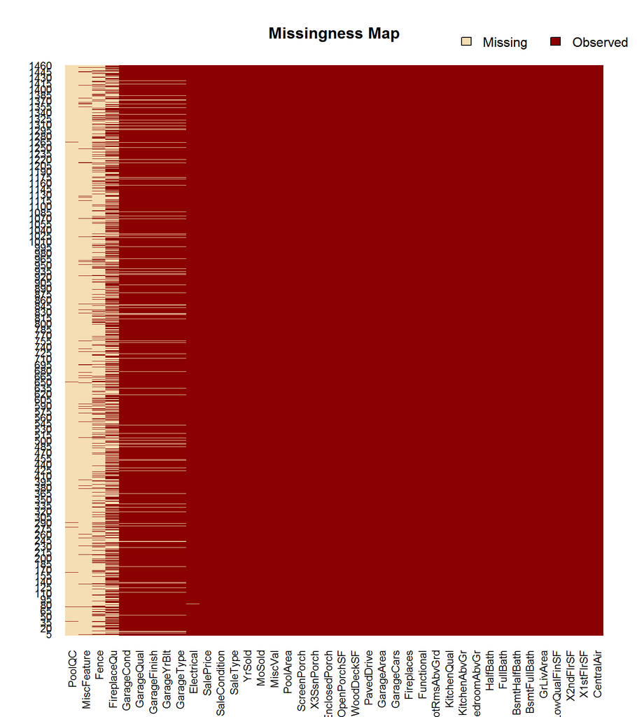

```r
missmap(RealEstateTrain[,c(42:81)])
```

Just based from the missing maps above, though rather fuzzy, I can already see that *Fence*, *MiscFeature* and *Alley Quality* are right up there among the top few variables with high number of missing values..

### Planned Analysis

With so many features in this dataset, it may make some sense to do some feature engineering - removal of highly correlated variables through methods such as Lasso - Elastic Net etc.. Alternatively, I can also experiment with random forest which randomly samples features at each tree growth which should reduce the multicollinearity problem too. I will also be interested to try out gradient boosting methods as I have seen it perform relatively well in Kaggle prediction - related competition.

The next plan is to fix some **NA** for some numeric variables which had some degree of NAs; I am trying to fix those variables rather than discard them from the analysis completely..The variables of interest are *GarageYrBlt and LotFrontage*

```r
 sapply(RealEstateTrain[,c("GarageYrBlt","LotFrontage")],function(x) sum(is.na(x)))
```

```
## GarageYrBlt LotFrontage
##          81         259
```

```r
RealEstateTrain$GarageYrBlt[is.na(RealEstateTrain$GarageYrBlt)]<-0
RealEstateTrain$LotFrontage[is.na(RealEstateTrain$LotFrontage)]<-0
```

I will be omitting some variable due to the large number of NAs which they possessed; namely *Fence, MiscFeature, Alley Quality* and *PoolQC*. These are qualitative variables which I can’t just recode the NAs into 0. Besides these variables, I will also be removing some variables which are problematic because there are just no *variation* between the categorical levels. Just take a look at *Utilities* and *MiscVal* individually.

```r
#Are there enough variation between categories?
table(RealEstateTrain$MiscVal)
```

```
##
##     0    54   350   400   450   480   500   560   600   620   700   800
##  1408     1     1    11     4     2     8     1     4     1     5     1
##  1150  1200  1300  1400  2000  2500  3500  8300 15500
##     1     2     1     1     4     1     1     1     1
```

```r
table(RealEstateTrain$Utilities)
```

```
##
## AllPub NoSeWa
##   1459      1
```

```r
#Creating a new data frame with these variables omitted
RealEstateTrain2<-RealEstateTrain[,c(2:6,8:9,11:72,77:81)]
```

I will also separate the original training dataset into a training & validation set respective. I am trying 60% - 40% split

```r
library(caret)
set.seed(1234)

partition<-createDataPartition(RealEstateTrain2$SalePrice,p=0.6,list=F)

training<-RealEstateTrain2[partition,]

validation<-RealEstateTrain2[-partition,]
```

Next, I will just be throwing all the regression into a model; in this case a linear regression model as SalePrice is a continuous/numeric variable.

```r
linearmodel<-lm(SalePrice ~. , data=training)

#Inspecting the regression output

summary(linearmodel)
```

```
##
## Call:
## lm(formula = SalePrice ~ ., data = training)
##
## Residuals:
##     Min      1Q  Median      3Q     Max
## -120738  -10505       0    9472  100197
##
## Coefficients: (7 not defined because of singularities)
##                        Estimate Std. Error t value Pr(>|t|)
## (Intercept)          -2.389e+06  2.776e+06  -0.861 0.390235
## MSSubClass            1.148e+02  2.767e+02   0.415 0.678643
## MSZoningRL           -1.948e+04  1.286e+04  -1.515 0.131059
## MSZoningRM           -1.537e+04  1.906e+04  -0.806 0.420827
## LotFrontage           8.037e+00  5.603e+01   0.143 0.886066
## LotArea               6.531e-01  3.769e-01   1.733 0.084447 .
## StreetPave            1.221e+05  6.631e+04   1.842 0.066766 .
## LotShapeIR2           1.438e+04  1.356e+04   1.060 0.290085
## LotShapeIR3          -1.373e+04  1.871e+04  -0.734 0.463838
## LotShapeReg           1.858e+03  3.830e+03   0.485 0.628109
## LandContourHLS        3.799e+03  1.630e+04   0.233 0.815874
## LandContourLow       -2.503e+04  1.999e+04  -1.252 0.211818
## LandContourLvl       -3.702e+03  1.219e+04  -0.304 0.761555
## LotConfigCulDSac     -3.864e+03  7.771e+03  -0.497 0.619471
## LotConfigFR2         -1.914e+04  1.227e+04  -1.561 0.119957
## LotConfigInside      -8.654e+03  4.452e+03  -1.944 0.053092 .
## LandSlopeMod         -1.897e+04  1.208e+04  -1.570 0.117701
## LandSlopeSev         -1.618e+04  3.323e+04  -0.487 0.626645
## NeighborhoodBlueste  -1.028e+04  3.626e+04  -0.283 0.777092
## NeighborhoodBrkSide  -5.833e+03  2.902e+04  -0.201 0.840879
## NeighborhoodClearCr  -4.552e+04  2.157e+04  -2.110 0.035904 *
## NeighborhoodCollgCr  -1.491e+04  1.445e+04  -1.032 0.302983
## NeighborhoodCrawfor   7.101e+03  2.034e+04   0.349 0.727305
## NeighborhoodEdwards  -1.871e+04  2.160e+04  -0.866 0.387377
## NeighborhoodGilbert  -1.518e+04  1.615e+04  -0.940 0.348179
## NeighborhoodIDOTRR   -2.220e+04  3.826e+04  -0.580 0.562198
## NeighborhoodMeadowV  -4.245e+04  3.577e+04  -1.187 0.236540
## NeighborhoodMitchel  -1.384e+04  2.068e+04  -0.669 0.503948
## NeighborhoodNAmes    -3.734e+04  1.864e+04  -2.004 0.046221 *
## NeighborhoodNoRidge   4.437e+03  1.712e+04   0.259 0.795733
```

[output cut: 163 more lines]

```
## SaleTypeConLI        -2.873e+04  2.928e+04  -0.981 0.327448
## SaleTypeConLw        -2.826e+04  3.236e+04  -0.874 0.383254
## SaleTypeNew           3.360e+04  2.013e+04   1.669 0.096377 .
## SaleTypeWD           -8.480e+03  1.911e+04  -0.444 0.657561
## SaleConditionAlloca   8.296e+04  4.928e+04   1.683 0.093597 .
## SaleConditionFamily  -1.234e+04  1.735e+04  -0.711 0.477550
## SaleConditionNormal   2.129e+04  1.034e+04   2.059 0.040541 *
## SaleConditionPartial         NA         NA      NA       NA
## ---
## Signif. codes:  0 '***' 0.001 '**' 0.01 '*' 0.05 '.' 0.1 ' ' 1
##
## Residual standard error: 26280 on 240 degrees of freedom
##   (444 observations deleted due to missingness)
## Multiple R-squared:  0.9487, Adjusted R-squared:  0.9074
## F-statistic: 22.98 on 193 and 240 DF,  p-value: < 2.2e-16
```

It appears that multicollnearity is making the model drop some of the highly correlated variables such as *TotalBsmtSF*. That is a good sign! I will also be recoding some categorical variables which are a little lopsided (inbalanced between categories) such as *LotShape, Condiiton1 & Condition2*

```r
#Recoding LotShape to either "Regular" shape or "Not Regular" shape
training$RegularShape[training$LotShape!="Reg"]<-"Not Reg"
training$RegularShape[training$LotShape=="Reg"]<-"Reg"

#Conversion to factors
training$RegularShape<-factor(training$RegularShape,levels=c("Reg","Not Reg"))

#Recoding Condition to either "Normal" or "Not Normal"
training$NewCondition1[training$Condition1!="Norm"]<-"Not Norm"
training$NewCondition1[training$Condition1=="Norm"]<-"Norm"
training$NewCondition2[training$Condition2!="Norm"]<-"Not Norm"
training$NewCondition2[training$Condition2=="Norm"]<-"Norm"

#Conversion to factors
training$NewCondition1<-factor(training$NewCondition1,levels=c("Norm","Not Norm"))
training$NewCondition2<-factor(training$NewCondition2,levels=c("Norm","Not Norm"))

#Removing the old variables --> LotShape, Condition 1 & Condition2
training<-training[,c(-6,-11,-12)]
```

Now, I will rerun the regression model again, using the new recoded variables. *New Condition2* is statistically significant, and it shows that having “Not Normal” conditions would have a negative impact on SalesPrice as compared compared to “Normal” conditions.

```r
linearmodel<-lm(SalePrice~.,data=training)

summary(linearmodel)
```

```
##
## Call:
## lm(formula = SalePrice ~ ., data = training)
##
## Residuals:
##     Min      1Q  Median      3Q     Max
## -121612  -10657       0    9779  100142
##
## Coefficients: (6 not defined because of singularities)
##                         Estimate Std. Error t value Pr(>|t|)
## (Intercept)           -1.998e+06  2.724e+06  -0.734 0.463875
## MSSubClass             1.323e+02  2.703e+02   0.490 0.624892
## MSZoningRL            -2.005e+04  1.247e+04  -1.608 0.109045
## MSZoningRM            -1.610e+04  1.875e+04  -0.858 0.391502
## LotFrontage            1.099e+01  5.306e+01   0.207 0.836149
## LotArea                7.356e-01  3.449e-01   2.133 0.033941 *
## StreetPave             1.410e+05  6.348e+04   2.222 0.027218 *
## LandContourHLS         2.946e+03  1.601e+04   0.184 0.854149
## LandContourLow        -2.917e+04  1.935e+04  -1.508 0.132943
## LandContourLvl        -4.436e+03  1.198e+04  -0.370 0.711585
## LotConfigCulDSac      -2.913e+03  7.496e+03  -0.389 0.697886
## LotConfigFR2          -1.940e+04  1.175e+04  -1.651 0.099908 .
## LotConfigInside       -8.569e+03  4.401e+03  -1.947 0.052658 .
## LandSlopeMod          -1.699e+04  1.178e+04  -1.443 0.150386
## LandSlopeSev          -1.400e+04  3.158e+04  -0.443 0.657861
## NeighborhoodBlueste   -1.159e+04  3.570e+04  -0.325 0.745694
## NeighborhoodBrkSide   -7.333e+03  2.800e+04  -0.262 0.793621
## NeighborhoodClearCr   -4.405e+04  2.125e+04  -2.073 0.039256 *
## NeighborhoodCollgCr   -1.332e+04  1.422e+04  -0.937 0.349853
## NeighborhoodCrawfor    6.386e+03  1.982e+04   0.322 0.747581
## NeighborhoodEdwards   -1.755e+04  2.115e+04  -0.830 0.407488
## NeighborhoodGilbert   -1.389e+04  1.588e+04  -0.875 0.382457
## NeighborhoodIDOTRR    -1.964e+04  3.733e+04  -0.526 0.599204
## NeighborhoodMeadowV   -4.396e+04  3.493e+04  -1.258 0.209401
## NeighborhoodMitchel   -1.391e+04  2.037e+04  -0.683 0.495330
## NeighborhoodNAmes     -3.777e+04  1.836e+04  -2.057 0.040696 *
## NeighborhoodNoRidge    4.460e+03  1.687e+04   0.264 0.791761
## NeighborhoodNPkVill    1.406e+03  3.269e+04   0.043 0.965736
## NeighborhoodNridgHt    9.250e+03  1.425e+04   0.649 0.516975
## NeighborhoodNWAmes    -3.939e+04  1.766e+04  -2.230 0.026648 *
```

[output cut: 155 more lines]

```
## SaleTypeWD            -7.373e+03  1.854e+04  -0.398 0.691132
## SaleConditionAlloca    7.541e+04  4.842e+04   1.558 0.120622
## SaleConditionFamily   -1.273e+04  1.709e+04  -0.745 0.457057
## SaleConditionNormal    2.042e+04  1.012e+04   2.018 0.044629 *
## SaleConditionPartial          NA         NA      NA       NA
## RegularShapeNot Reg   -1.757e+03  3.749e+03  -0.469 0.639692
## NewCondition1Not Norm -1.362e+03  5.393e+03  -0.253 0.800782
## NewCondition2Not Norm -5.126e+05  3.984e+04 -12.867  < 2e-16 ***
## ---
## Signif. codes:  0 '***' 0.001 '**' 0.01 '*' 0.05 '.' 0.1 ' ' 1
##
## Residual standard error: 26030 on 247 degrees of freedom
##   (444 observations deleted due to missingness)
## Multiple R-squared:  0.9482, Adjusted R-squared:  0.9092
## F-statistic:  24.3 on 186 and 247 DF,  p-value: < 2.2e-16
```

I will also be doing the variable recoding on the validation dataset because I will be using the dataset to validate for prediction’s accuracy (RMSE)

```r
#Recoding LotShape to either "Regular" shape or "Not Regular" shape
validation$RegularShape[validation$LotShape!="Reg"]<-"Not Reg"
validation$RegularShape[validation$LotShape=="Reg"]<-"Reg"

#Conversion to factors
validation$RegularShape<-factor(validation$RegularShape,levels=c("Reg","Not Reg"))

#Recoding Condition to either "Normal" or "Not Normal"
validation$NewCondition1[validation$Condition1!="Norm"]<-"Not Norm"
validation$NewCondition1[validation$Condition1=="Norm"]<-"Norm"
validation$NewCondition2[validation$Condition2!="Norm"]<-"Not Norm"
validation$NewCondition2[validation$Condition2=="Norm"]<-"Norm"

#Conversion to factors
validation$NewCondition1<-factor(validation$NewCondition1,levels=c("Norm","Not Norm"))
validation$NewCondition2<-factor(validation$NewCondition2,levels=c("Norm","Not Norm"))

#Removing the old variables --> LotShape, Condition 1 & Condition2
validation<-validation[,c(-6,-11,-12)]
```

## Feature Engineering

Feature engineering is an important aspect of a data worflow or analysis project. This is even especially so when we have a dataset with a large number of possible predictor variables. All the variables might not be important from a predictive analysis point of view and it is critical that we bring a balance of complexity and benefit in the final model accuracy *(RMSE in this place)*

There are different variants of Feature Engineering, but they fall broadly into these 3 groups namely:

- Filter Methods
- Wrapper Methods
- Embedded Methods

In this analysis, I wouldn’t have the time to go deeply into all 3 methods. But for the purpose of this analysis, I will be focusing on the stepwise regression (backward selection) which falls under the category of the Wrapper methodology. Basically this algorithm, starts with a *full* model and then reiterates itself; removing variables at each reiteration and then benchmarking itself against an information criterion measure (AIC..etc). Variables will be removed from the regression model to the point that any further of predictor variables would not improve the AIC further.This final model would then contain the *optimal* number of predictor variables selected to acheive the best model fit without compromising accuracy.

```r
library(MASS)

#I have to remove all the na values prior to running the stepAIC function
training_naomit<-na.omit(training)

linearmodel_naomit<-lm(SalePrice ~.,data=training_naomit)

#Running the backward selection algorithm

stepAIC(linearmodel_naomit,direction="backward",trace=FALSE)
```

```
##
## Call:
## lm(formula = SalePrice ~ MSSubClass + MSZoning + LotArea + Street +
##     LotConfig + LandSlope + Neighborhood + OverallQual + OverallCond +
##     YearBuilt + RoofStyle + RoofMatl + Exterior1st + Exterior2nd +
##     MasVnrArea + BsmtExposure + BsmtFinType1 + BsmtFinSF1 + BsmtFinSF2 +
##     BsmtUnfSF + X1stFlrSF + X2ndFlrSF + LowQualFinSF + FullBath +
##     BedroomAbvGr + TotRmsAbvGrd + Functional + GarageCars + EnclosedPorch +
##     ScreenPorch + PoolArea + MoSold + SaleCondition + NewCondition2,
##     data = training_naomit)
##
## Coefficients:
##           (Intercept)             MSSubClass             MSZoningRL
##            -1.612e+06             -1.643e+02             -2.000e+04
##            MSZoningRM                LotArea             StreetPave
##            -2.241e+04              5.146e-01              6.055e+04
##      LotConfigCulDSac           LotConfigFR2        LotConfigInside
##            -3.807e+02             -1.538e+04             -5.991e+03
##          LandSlopeMod           LandSlopeSev    NeighborhoodBlueste
##            -2.232e+04             -1.426e+04              2.192e+03
##   NeighborhoodBrkSide    NeighborhoodClearCr    NeighborhoodCollgCr
##             7.588e+03             -1.709e+04             -1.610e+03
##   NeighborhoodCrawfor    NeighborhoodEdwards    NeighborhoodGilbert
##             2.311e+04              2.072e+03             -6.980e+03
##    NeighborhoodIDOTRR    NeighborhoodMeadowV    NeighborhoodMitchel
##             6.370e+03             -2.605e+04             -1.938e+03
##     NeighborhoodNAmes    NeighborhoodNoRidge    NeighborhoodNPkVill
##            -1.443e+04              1.288e+04              2.543e+04
##   NeighborhoodNridgHt     NeighborhoodNWAmes    NeighborhoodOldTown
##             2.289e+04             -2.053e+04             -6.156e+03
##    NeighborhoodSawyer    NeighborhoodSawyerW    NeighborhoodSomerst
##             3.559e+03             -6.364e+03             -6.818e+03
##   NeighborhoodStoneBr      NeighborhoodSWISU     NeighborhoodTimber
##             4.792e+04             -1.806e+04             -1.005e+04
##   NeighborhoodVeenker           OverallQual4           OverallQual5
##            -1.798e+04              2.203e+04              6.505e+03
##          OverallQual6           OverallQual7           OverallQual8
##             1.050e+03              6.060e+03              1.723e+04
##          OverallQual9          OverallQual10            OverallCond
##             5.799e+04              8.528e+04              1.070e+04
```

[output cut: 31 more lines]

```
##             3.532e+01              2.114e+01              6.028e+01
##             X2ndFlrSF           LowQualFinSF               FullBath
##             7.117e+01              7.437e+01              7.870e+03
##          BedroomAbvGr           TotRmsAbvGrd         FunctionalMaj2
##            -9.404e+03              4.584e+03             -1.798e+04
##        FunctionalMin1         FunctionalMin2          FunctionalMod
##            -3.928e+03              1.402e+04             -4.539e+04
##         FunctionalTyp             GarageCars          EnclosedPorch
##             1.323e+04              6.932e+03              3.580e+01
##           ScreenPorch               PoolArea                 MoSold
##             6.528e+01             -1.190e+02             -6.223e+02
##   SaleConditionAlloca    SaleConditionFamily    SaleConditionNormal
##             3.748e+04             -7.797e+03              1.952e+04
##  SaleConditionPartial  NewCondition2Not Norm
##             4.361e+04             -5.028e+05
```

```r
#Selecting the predictor that were selected by the backwards selection algorithm

modelformula<-as.formula(SalePrice ~ MSSubClass + MSZoning + LotArea + Street +
LotConfig + LandSlope + Neighborhood + OverallQual + OverallCond +
YearBuilt + RoofStyle + RoofMatl + Exterior1st + Exterior2nd +
MasVnrArea + BsmtExposure + BsmtFinType1 + BsmtFinSF1 + BsmtFinSF2 +
BsmtUnfSF + X1stFlrSF + X2ndFlrSF + LowQualFinSF + FullBath +
BedroomAbvGr + TotRmsAbvGrd + Functional + GarageCars + EnclosedPorch +
ScreenPorch + PoolArea + MoSold + SaleCondition + NewCondition2)
```

Now lets run the regression model with the selected variable and inspect its output.

```r
linearmodel2<-lm(modelformula,data=training)

summary(linearmodel2)
```

```
##
## Call:
## lm(formula = modelformula, data = training)
##
## Residuals:
##     Min      1Q  Median      3Q     Max
## -272956  -10760     544   10136  131562
##
## Coefficients: (1 not defined because of singularities)
##                         Estimate Std. Error t value Pr(>|t|)
## (Intercept)           -1.309e+06  1.962e+05  -6.674 4.91e-11 ***
## MSSubClass            -1.702e+02  3.253e+01  -5.231 2.21e-07 ***
## MSZoningFV             2.233e+04  1.654e+04   1.350  0.17747
## MSZoningRH             1.669e+04  1.724e+04   0.968  0.33341
## MSZoningRL             9.681e+03  1.419e+04   0.682  0.49525
## MSZoningRM             4.032e+03  1.350e+04   0.299  0.76523
## LotArea                2.632e-01  1.577e-01   1.669  0.09551 .
## StreetPave             2.898e+04  1.648e+04   1.759  0.07898 .
## LotConfigCulDSac      -5.143e+02  4.450e+03  -0.116  0.90803
## LotConfigFR2          -1.355e+04  6.155e+03  -2.201  0.02806 *
## LotConfigFR3           2.639e+04  1.928e+04   1.369  0.17147
## LotConfigInside       -5.989e+03  2.481e+03  -2.414  0.01604 *
## LandSlopeMod          -7.132e+03  5.095e+03  -1.400  0.16197
## LandSlopeSev           3.723e+03  1.463e+04   0.254  0.79921
## NeighborhoodBlueste    1.327e+03  2.767e+04   0.048  0.96176
## NeighborhoodBrDale    -2.981e+03  1.462e+04  -0.204  0.83853
## NeighborhoodBrkSide    1.278e+04  1.268e+04   1.008  0.31370
## NeighborhoodClearCr   -1.099e+04  1.295e+04  -0.849  0.39614
## NeighborhoodCollgCr   -2.954e+03  9.962e+03  -0.297  0.76691
## NeighborhoodCrawfor    2.223e+04  1.206e+04   1.844  0.06563 .
## NeighborhoodEdwards   -1.995e+04  1.116e+04  -1.788  0.07418 .
## NeighborhoodGilbert   -6.255e+03  1.057e+04  -0.592  0.55418
## NeighborhoodIDOTRR    -3.082e+03  1.394e+04  -0.221  0.82502
## NeighborhoodMeadowV    2.742e+03  1.554e+04   0.176  0.86004
## NeighborhoodMitchel   -8.410e+03  1.111e+04  -0.757  0.44913
## NeighborhoodNAmes     -1.336e+04  1.076e+04  -1.242  0.21474
## NeighborhoodNoRidge    3.358e+04  1.204e+04   2.789  0.00542 **
## NeighborhoodNPkVill    1.040e+04  2.084e+04   0.499  0.61786
## NeighborhoodNridgHt    3.308e+04  1.045e+04   3.166  0.00161 **
## NeighborhoodNWAmes    -1.407e+04  1.091e+04  -1.289  0.19771
```

[output cut: 79 more lines]

```
## PoolArea              -1.032e+02  6.041e+01  -1.708  0.08812 .
## MoSold                -5.684e+02  3.442e+02  -1.651  0.09914 .
## SaleConditionAdjLand   2.400e+04  2.581e+04   0.930  0.35287
## SaleConditionAlloca    3.224e+03  1.306e+04   0.247  0.80507
## SaleConditionFamily   -1.750e+04  8.826e+03  -1.983  0.04774 *
## SaleConditionNormal    5.350e+03  3.913e+03   1.367  0.17195
## SaleConditionPartial   2.276e+04  5.352e+03   4.253 2.38e-05 ***
## NewCondition2Not Norm -9.033e+04  1.221e+04  -7.396 3.85e-13 ***
## ---
## Signif. codes:  0 '***' 0.001 '**' 0.01 '*' 0.05 '.' 0.1 ' ' 1
##
## Residual standard error: 24900 on 734 degrees of freedom
##   (28 observations deleted due to missingness)
## Multiple R-squared:  0.9144, Adjusted R-squared:  0.9009
## F-statistic: 68.14 on 115 and 734 DF,  p-value: < 2.2e-16
```

We see that there is barely any drop in the R square, but then again, there are some predictors that are not statistically significant at all. Statistically speaking, these predictors are not contributing to the predictive power of the regression model. Lets see whether removing them, would affect R square significantly? For a start, I am removing predictors with higher P values, those that are marginally close to 0.05, I am still leaving those in the model.

The predictor variables that I am removing are *MSZoning, Neighborhood, Roofstyle, Exterior1st & Exterior2nd*

```r
modelformula2<-as.formula(SalePrice ~ MSSubClass + LotArea + Street +
LotConfig + LandSlope + OverallQual + OverallCond +
YearBuilt + RoofMatl + MasVnrArea + BsmtExposure + BsmtFinType1 + BsmtFinSF1 + BsmtFinSF2 +
BsmtUnfSF + X1stFlrSF + X2ndFlrSF + LowQualFinSF + FullBath +
BedroomAbvGr + TotRmsAbvGrd + Functional + GarageCars + EnclosedPorch +
ScreenPorch + PoolArea + MoSold + SaleCondition + NewCondition2)


linearmodel3<-lm(modelformula2,data=training)


anova(linearmodel3,linearmodel2)
```

```
## Analysis of Variance Table
##
## Model 1: SalePrice ~ MSSubClass + LotArea + Street + LotConfig + LandSlope +
##     OverallQual + OverallCond + YearBuilt + RoofMatl + MasVnrArea +
##     BsmtExposure + BsmtFinType1 + BsmtFinSF1 + BsmtFinSF2 + BsmtUnfSF +
##     X1stFlrSF + X2ndFlrSF + LowQualFinSF + FullBath + BedroomAbvGr +
##     TotRmsAbvGrd + Functional + GarageCars + EnclosedPorch +
##     ScreenPorch + PoolArea + MoSold + SaleCondition + NewCondition2
## Model 2: SalePrice ~ MSSubClass + MSZoning + LotArea + Street + LotConfig +
##     LandSlope + Neighborhood + OverallQual + OverallCond + YearBuilt +
##     RoofStyle + RoofMatl + Exterior1st + Exterior2nd + MasVnrArea +
##     BsmtExposure + BsmtFinType1 + BsmtFinSF1 + BsmtFinSF2 + BsmtUnfSF +
##     X1stFlrSF + X2ndFlrSF + LowQualFinSF + FullBath + BedroomAbvGr +
##     TotRmsAbvGrd + Functional + GarageCars + EnclosedPorch +
##     ScreenPorch + PoolArea + MoSold + SaleCondition + NewCondition2
##   Res.Df        RSS Df  Sum of Sq      F    Pr(>F)
## 1    790 5.9243e+11
## 2    734 4.5509e+11 56 1.3734e+11 3.9555 < 2.2e-16 ***
## ---
## Signif. codes:  0 '***' 0.001 '**' 0.01 '*' 0.05 '.' 0.1 ' ' 1
```

I compared both regression models using anova F test, and the results shows that including these predictor variables do help in the linear prediction (P value < 0.05). As this is more of a prediction project, I would be keeping these predictor within the models as I would want the most accurate prediction of housing *SalePrice*.

```r
#Due to some resultant error messages which appear because of new factor levels in some of the categories of the validation dataset, I had to remove some predictor variables before I can even run the prediction function. In the process, I removed Exterior1st, Exterior2nd, Functional, & RoofMat1

modelformula<-as.formula(SalePrice ~ MSSubClass + MSZoning + LotArea + Street +
LotConfig + LandSlope + Neighborhood + OverallCond +
YearBuilt + RoofStyle + MasVnrArea + BsmtExposure + BsmtFinType1 + BsmtFinSF1 + BsmtFinSF2 +
BsmtUnfSF + X1stFlrSF + X2ndFlrSF + LowQualFinSF + FullBath +
BedroomAbvGr + TotRmsAbvGrd + GarageCars + EnclosedPorch +
ScreenPorch + PoolArea + MoSold + SaleCondition + NewCondition2)

#Re - Running the new rgression model with these variables removed.

linearmodel2<-lm(modelformula,data=training)

linearmodelpred<-predict(linearmodel2,newdata=validation,type="response")

validationY<-validation$SalePrice

#Getting the log of the linear prediction
logpred<-log(linearmodelpred)
#Getting the log of the validation set Sale Price
logvalidationY<-log(validationY)

sqrt(mean((logpred - logvalidationY)^2,na.rm=TRUE))
```

```
## [1] 0.2344585
```

The log RMSE value is 0.23, lets see whether it improves with the random forest model.

## Random Forest

The first thing I would be doing is to find the optimal number of forest size ~ *ntree*. The reason being having too many trees may lead to overfitting, which is a bad thing. We can both look at the plot as well ask for the minimum MSE.

```r
library(randomForest)
set.seed(123)
rfTrees.imputed<-rfImpute(modelformula,data=training)
```

```
##      |      Out-of-bag   |
## Tree |      MSE  %Var(y) |
##  300 | 1.073e+09    17.23 |
##      |      Out-of-bag   |
## Tree |      MSE  %Var(y) |
##  300 | 1.035e+09    16.61 |
##      |      Out-of-bag   |
## Tree |      MSE  %Var(y) |
##  300 | 1.036e+09    16.64 |
##      |      Out-of-bag   |
## Tree |      MSE  %Var(y) |
##  300 | 1.002e+09    16.08 |
##      |      Out-of-bag   |
## Tree |      MSE  %Var(y) |
##  300 | 1.016e+09    16.31 |
```

As randomForest() function cannot run using a dataset with NAs in it, I had to impute missing values in the predictors using the proximity matrix from the randomforest model. I will use the newly created dataset *(NAs imputed)* to proceed with the random forest models.

Lets by default, run a random forest model and looks at its output before we proceed to do any form of parameter tuning.

```r
rfTree<-randomForest(modelformula,data=rfTrees.imputed)

rfTree
```

```
##
## Call:
##  randomForest(formula = modelformula, data = rfTrees.imputed)
##                Type of random forest: regression
##                      Number of trees: 500
## No. of variables tried at each split: 9
##
##           Mean of squared residuals: 1016630482
##                     % Var explained: 83.68
```

The call of the rfTrees object shows us that the above random forest generated 500 trees (by default) and sampled 9 variables at each split. It gave a MSE of 1016630482 and accounted for nearly 84% of variance explained.

Now, it is imperative that we do some parameter tuning to “get” the winning settings for the test - set prediction. However, before tuning other parameters such as mtry*(number features per tree)* and *nodesize*, we need to first see how large the forest needs to get. Hence, tuning the random forest model to obtain a parsimonous numbers of tree first is a very important step. Here our goal is to find the point where RMSE is minimised across the sequence of tree sizes which we had specified earlier.

```r
bseq=100*c(seq(2,10,2),15,20,30)


#Creating a list to store the random forest predictions later on
rfList<-vector("list",length(bseq))


#Writing a for loop to run run a random forest model at each sequence and then storing its OOB predictions
for(i in 1:length(bseq)){
  set.seed(1234)
  rfmodel<-randomForest(modelformula,data=rfTrees.imputed,ntree=bseq[i])
  rfList[[i]]<-rfmodel$predicted
}

library(magrittr)

RMSE<-rep(NA,8)

for(i in 1:length(rfList)){
  RMSE[i]<-sqrt(mean((log(rfList[[i]]) - log(rfTrees.imputed$SalePrice))^2,na.rm=TRUE))
}

#Lets get the winning tree choice!

RMSE
```

```
## [1] 0.1659687 0.1650383 0.1647968 0.1643171 0.1646503 0.1646591 0.1645691
## [8] 0.1643940
```

```r
which.min(RMSE)
```

```
## [1] 4
```

From the output above, it is apparent that RMSE is minimised at the tree size of 800 (4th in the sequence of trees specified by me earlier).

After establishing how large our random forest tree is going to be, it is now time to get our hands dirty on tuning the other parameters. Specifically, the 2 main parameters we will be tuning will be *mtry* and *nodesize* respectively. *mtry* refers to the number of features sampled at each split while *nodesize* sets how small the terminal nodes are allowed to be. We will have to create a tuning grid which contains different combinations of *mtry* and *nodesize* and then write a for loop which runs a random forest for each of these tuning parameters’s combination.

```r
ftune<-expand.grid(m=seq(2,20,5),detail=c(1:4,6,8))

RMSEvalues<-rep(NA,24)

#Creating MSE function

RMSE<-function(x,y){
  pred<-x
  realY<-y
  RMSEvalue<-sqrt(mean((pred - realY)^2,na.rm=TRUE))
  return(RMSEvalue)
}

#2D tuning of mtry(features per tree) & nodesize using MSE as the evaluation criteria

for(i in 1:dim(ftune)[1]){
  set.seed(1234)
  tmp<-randomForest(modelformula,data=rfTrees.imputed,ntree=800,mtry=ftune$m[i],nodesize=ftune$detail[i])
  RMSEvalues[i]<-RMSE(log(tmp$predicted),log(rfTrees.imputed$SalePrice))
}


#Combining the ftune grid together with the MSE values
ftune<-cbind(ftune,RMSEvalues)

ftune[which.min(ftune$RMSEvalues),]
```

```
##     m detail RMSEvalues
## 19 12      6  0.1638432
```

```r
#mtry=12,ntree=800,nodesize=6
```

After initiating the for loop whereby we looped through every combination of *mtry* and *nodesize* in the tuning grid, we found the optimum combination of *mtry* and *nodesize* which is 12 and 6 respectively. We will then use these settings and refit the random forest to them. But prior to that, lets look at the 2D tuning plot of the *mtry* and *nodesize* (detail) parameters.

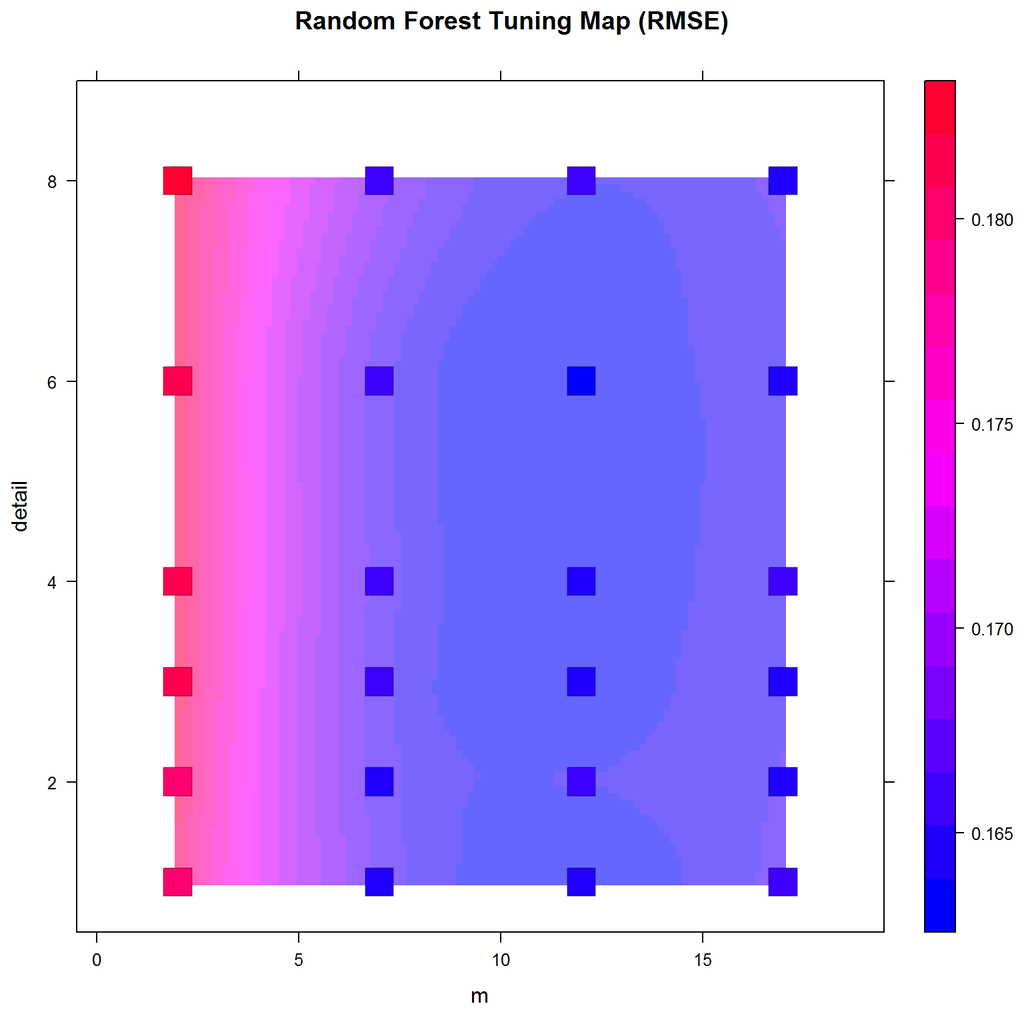

```r
library(latticeExtra)

levelplot(RMSEvalues~m+detail,data=ftune,panel=panel.levelplot.points,cex=3,pch=22,col.regions=rainbow(31,start=2/3),main="Random Forest Tuning Map (RMSE)") +
layer_(panel.2dsmoother(...,col.regions=rainbow(31,start=2/3,alpha=0.6)))
```

```r
set.seed(123)

optimrfTrees<-randomForest(modelformula,data=rfTrees.imputed,ntree=800,mtry=12,nodesize=6)

rftreepred<-predict(optimrfTrees,newdata=validation)

logrftreepred<-log(rftreepred)


#Getting the log RMSE value
sqrt(mean((logrftreepred - logvalidationY)^2,na.rm=TRUE))
```

```
## [1] 0.1556456
```

After fitting the *winning* tuning parameter settings to the new random forest model, we validate it by testing its predictions against the validation dataset. The RMSE value obtained is 0.155, which is already significantly lower than that of the linear regression model. The model fit here using the random forest is certaintly much better.

Now, lets look at some performance plots of the predicted VS observed values of both the linear regression and the random forest models. This is based on the validation dataset.

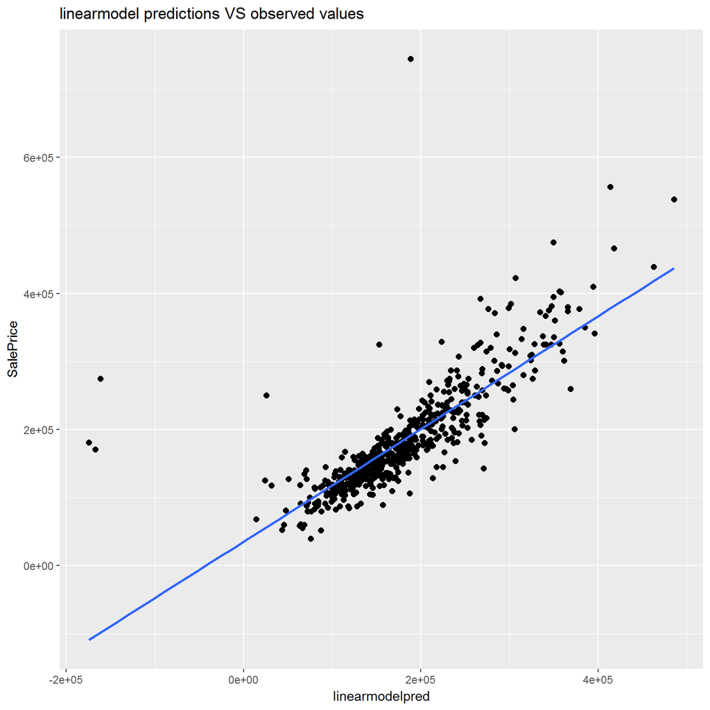

```r
library(ggplot2)

ggplot(validation,aes(x=linearmodelpred, y=SalePrice)) + geom_point(size=2) + labs(title="linearmodel predictions VS observed values") + stat_smooth(method=lm,se=FALSE)
```

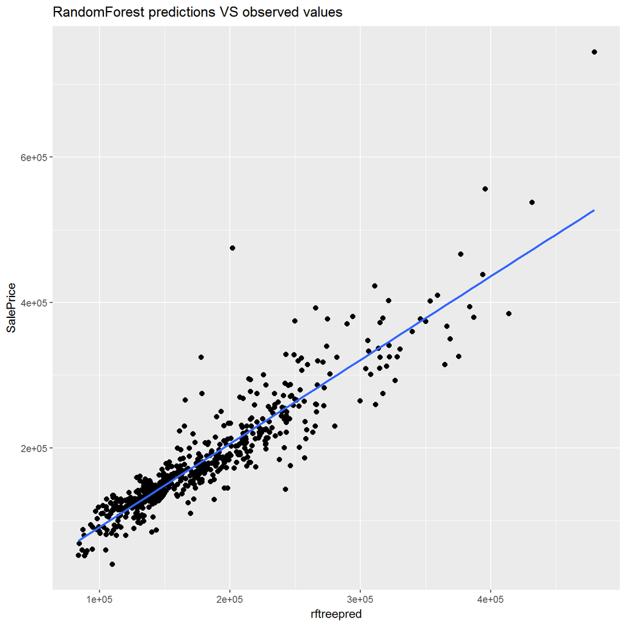

```r
ggplot(validation,aes(x=rftreepred,y=SalePrice)) + geom_point(size=2) + labs(title="RandomForest predictions VS observed values") + stat_smooth(method=lm,se=FALSE)
```

From the scatterplots above, we can see that the prediction & observed points are converging a little more closer for the random forest model as compared to that of the linear regression model. This is one good way for visualizing how much better the random forest model fits the data. However,visualization itself can only validate so much. For a more robust indicator on how the models perform respectively against the validation dataset is to look at their RMSE value **(based on logarithm of SalePrice & Predictions)**

It is clear that the random forest model performs better, and with that in mind, I will be using it to predict the SalePrice of the test dataset. However, there are some data preparation that I need to perform on the testing dataset first.

```r
RealEstateTest<-read.csv("C:/Users/Eugene Chua/Documents/Real_Estate_test.csv",header=TRUE)

dim(RealEstateTest)
```

```
## [1] 1459   80
```

```r
Test<-RealEstateTest[,c(2:6,8:9,11:72,77:80)]


#Recoding LotShape to either "Regular" shape or "Not Regular" shape
Test$RegularShape[Test$LotShape!="Reg"]<-"Not Reg"
Test$RegularShape[Test$LotShape=="Reg"]<-"Reg"

#Conversion to factors
Test$RegularShape<-factor(Test$RegularShape,levels=c("Reg","Not Reg"))

#Recoding Condition to either "Normal" or "Not Normal"
Test$NewCondition1[Test$Condition1!="Norm"]<-"Not Norm"
Test$NewCondition1[Test$Condition1=="Norm"]<-"Norm"
Test$NewCondition2[Test$Condition2!="Norm"]<-"Not Norm"
Test$NewCondition2[Test$Condition2=="Norm"]<-"Norm"

#Conversion to factors
Test$NewCondition1<-factor(Test$NewCondition1,levels=c("Norm","Not Norm"))
Test$NewCondition2<-factor(Test$NewCondition2,levels=c("Norm","Not Norm"))

#Removing the old variables --> LotShape, Condition 1 & Condition2
Test<-Test[,c(-6,-11,-12)]
```

```r
testsetpred<-predict(optimrfTrees,newdata=Test)

length(testsetpred)
```

```
## [1] 1459
```

```r
#Creating a new test dataframe whereby I match the predicted Sale Price to the House ID

SalePrice_Test<-data.frame(RealEstateTest$Id,SalePrice=testsetpred)

head(SalePrice_Test,8)
```

```
##   RealEstateTest.Id SalePrice
## 1              1461  123902.4
## 2              1462  156403.5
## 3              1463  185359.4
## 4              1464  181820.6
## 5              1465  202905.8
## 6              1466  193057.7
## 7              1467  181680.0
## 8              1468  174544.2
```